# Replication of Study Black and White Lies:Race-Based Biases in Deception Judgements (2017, Psychological Science)

E. Paige Lloyd, Kurt Hugenberg, Allen R. McConnel, Jonathan W. Kunstman, & Jason C. Deska

December 10, 2018

## Introduction

I am interested in understanding and correcting biases, especially in the context of social groups. This paper by Lloyd, Hugenberg, McConnel, Kunstman, & Deska (2017) examines the truth bias by understanding how group membership influences perceivers decisions on whether an individual is seen as deceiving or truthful. I plan to replication Study 1c, which found that White American participants used the truth response more for Black targets than for White targets. The paper also used the Open Science Framework, making it relatively easy to replicate.

Participants will be viewing one of two sets of 40 deception-judgement videos that are provided by the author. Each video will show an individual telling a story, and participants will determine whether the individual is lying or not. They will also be completing Plant and Devine’s (1998) Internal and External Motivation to Respond Without Prejudice measure, Glaser and Knowles’s (2008) Implicit Motivation to Control Prejudice task, and Kunstman et al. (2013) 17-item intergroup contact measure. Because I am not very familiar with amazon mechanical turk, I am expecting to have a some challenges within making sure that the stimuli will be represented correctly, without errors within the survey flow. Because I have not done statistical analysis for a while, I also expect some challenges within the data analysis bit. Fortunately, because the study is on OSF, I hope that it would be relatively easier to learn.

#### Repository

https://github.com/sakaria4/lloyd2017.git

#### Original paper

https://github.com/sakaria4/lloyd2017/tree/master/original_paper

## Methods

### Power Analysis

According to Lloyd et al.(2017), an a priori power analysis indicated that 67 participants are needed to achieve 80% power for the analysis.

Using their data in their achieved effect size of 1.09. I require 9 participants. I divided the effect size in half and using G*power indicated that I would need 27 participants.

### Planned Sample

27 White Americans

### Materials

- MU3D Videos
- Plant and Devine’s (1998) Internal and External Motivation to Respond Without Prejudice measure
- Glaser and Knowles’s (2008) Implicit Motivation to Control Prejudice task
- Kunstman et al. (2013) 17-item intergroup contact measure.

### Analysis Plan

Paired T-test between measurement of truth biases for black targets and white targets

### Differences from Original Study

Procedures were followed exactly as researchers reported.

### Methods Addendum (Post Data Collection)

#### Actual Sample

27 White American Participants

#### Differences from pre-data collection methods plan

none

## Results

### Data preparation

Data preparation following the analysis plan.

```r
library(tidyverse)
library(readxl)
library(effsize)
library(dplyr)
library(ggpubr)
#Used to clean up data and take out unnecessary data for study 1c
lloyd1c_wide <- read.csv("lloyd2017_data_modified.csv") %>%
  mutate(subId = rownames(.)) %>%
  select(starts_with("WM"), starts_with("BM"), subId, AttCheck1, AttnCheck2)
#Used to tidy data for analysis
lloyd1c_long <- lloyd1c_wide %>%
  gather(question, response, -subId, -AttCheck1, -AttnCheck2) %>%
  filter(!is.na(response), AttCheck1 == 5) %>%
  separate(question, into = c("race", "gender", "valence", "lie", "qnumber"), sep=1:4)

#Data prepped for t-test
lloyd1c_final <- lloyd1c_long %>%
  group_by(subId, race) %>%
  summarise(meanResponse = mean(response)) %>%
  spread(race, meanResponse)
```

### Confirmatory analysis

```r
#T-test on means of truth responses to each race
t.test(lloyd1c_final$B, lloyd1c_final$W, paired = TRUE)
```

```
##
##  Paired t-test
##
## data:  lloyd1c_final$B and lloyd1c_final$W
## t = 3.6168, df = 24, p-value = 0.001379
## alternative hypothesis: true difference in means is not equal to 0
## 95 percent confidence interval:
##  0.09445795 0.34554205
## sample estimates:
## mean of the differences
##                    0.22
```

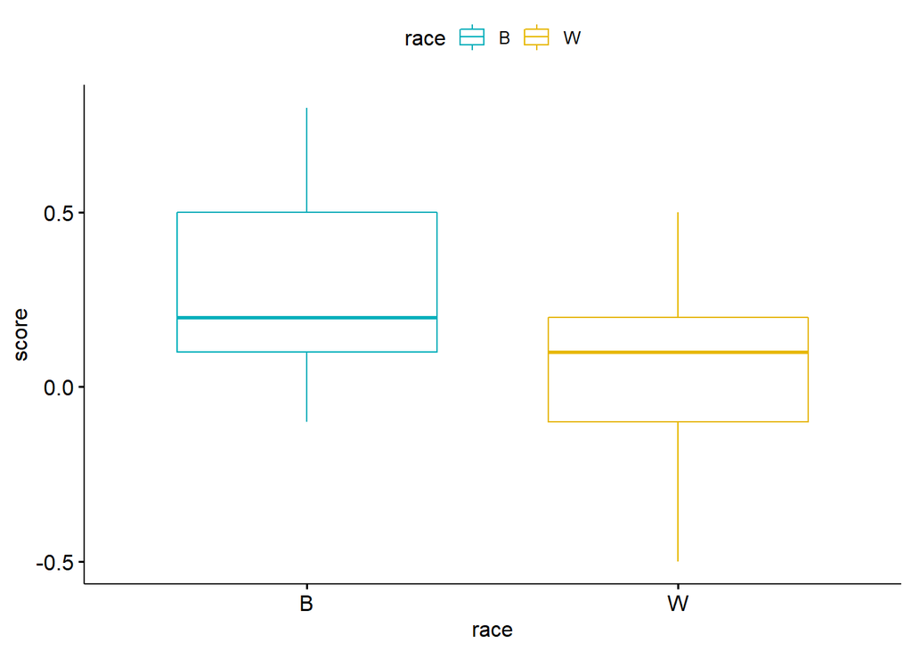

```r
#Preparing data for box plot
lloyd1c_plot <- lloyd1c_final%>%
  gather(race, score, -subId)

#Boxplot showing range of responses from participants.
#Score plotted are means of participants responses. Scores range from 1 to -1. Higher scores indicate higher tendency to use truth response.
ggboxplot(lloyd1c_plot, x = "race", y = "score",
          color = "race", palette = c("#00AFBB", "#E7B800"),
          order = c("B", "W"),
          ylab = "score", xlab = "race")
```

## Discussion

### Summary of Replication Attempt

With 25 participants for the final analysis (2 excluded for attention check failure), a paired t-test was ran. The result was significant with p=.001, suggesting that participants were more likely to favor truth responses for black targets rather than white targets. This finding replicates the Lloyd et al. (2016) study 1c result.

### Commentary

I believe that this study was accurate replication of Lloyd et al. (2016) study 1c findings. With the help of the original researchers, I was able to acquire materials and procedures necessary for a successful replication. Through the presentation and discussion of this replication, I came across an interesting question on the content of the MU3D video. I think these videos were controlled very well for length, valence, and lie/truth content as described in the supplemental material. However, I did not find information on how target attractiveness was controlled. One possibility is that participants may have been using physical attractiveness as a cue for lie/truth detection. It would be interesting to see if the black or white target videos could also be indexed based on perceived attractiveness as previous research within the paper indicates that attractiveness can influence trustworthiness judgements. Having the MU3D videos being controlled for attractiveness could make this finding more powerful.